# Task 4: Naples Reef Purple Urchins

Sophia Leiker

10/29/2021

# Setup

- Attaching packages
- Setting code chunk options

```r
knitr::opts_chunk$set(echo = TRUE,warning = FALSE, message = FALSE)

#Attaching packages
library(here)
library(tidyverse)
library(janitor)
library(kableExtra)
library(lubridate)
```

# Overview

In this data analysis, I am using data for purple urchins observed at 5 sites along the Santa Barbara coast to assess mean size comparisons in relation to a control group where there was no giant kelp removal versus an annual treatment where there was annual kelp removal. This analysis focuses on the Naples Reef in 2010.

We are using historgrams and quantile-quantile plots to first visually inspect if the distribution looks normal, and then using QQ plots to assess the normal distribution. If the data is normally distributed, the then when plotting quantiles vs theoretical normal quantiles, there should be a linear looking relationship.

*Data Citation: Reed, D. 2020. SBC LTER: Reef: Long-term experiment: Kelp removal: Urchin size frequency distribution ver 20. Environmental Data Initiative. https://doi.org/10.6073/pasta/5a1e9ef03aa47bd2225c0bb98a02a63b.*

# Section 1: Purple Urchins at Naples Reef in 2010

### 1.1 Reading in the data

- Reading in the urchins data set using here()
- Cleaning up the column names to lower snake

```r
urchins <- read_csv(here("data", "urchins.csv"), show_col_types = FALSE)

#Cleaning up the column names
urchins <- clean_names(urchins)
```

### 1.2 Filtering to only include data from:

- Purple Urchins
- Naples Reef
- Year 2010

```r
naples_urchins <- urchins %>%
  filter(common_name == "Purple Urchin", site == "NAPL") %>% #checked using unique(naples_urchins$common_name)
  mutate(date = mdy(date)) %>% #checking using class(purple_urchins$date)
  mutate(year = year(date)) %>%
  filter(year == 2010)
```

# Section 2: Exploratory Histograms & QQ Plots: Urchin Sizes

- Exploring Histogram Distributions of sea urchin size
- Exploring QQ Plots of sea urchin size

### 2.1 Histograms

Testing out histograms with different bid widths to assess normality of urchin sizes at the control plots vs the annual plots. These histograms are plotting frequency of observations within the bins

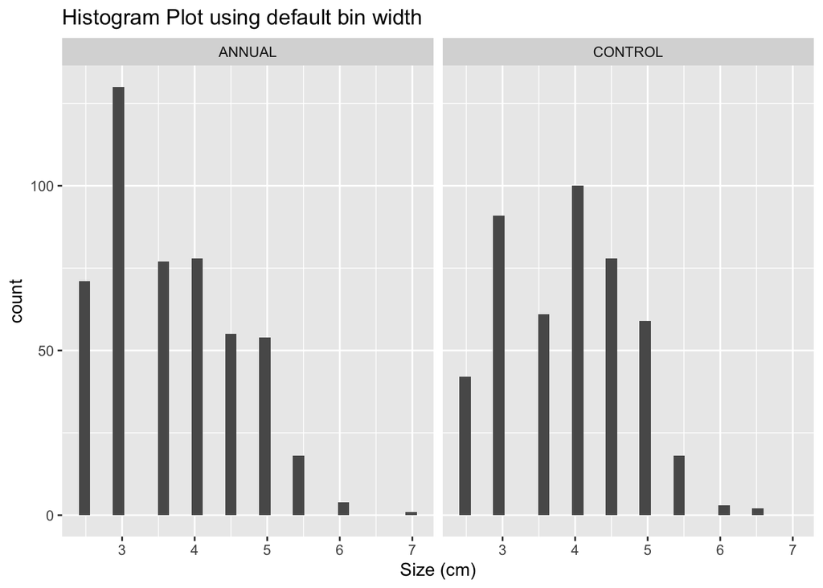

```r
ggplot(data = naples_urchins, aes(x= size)) +
  geom_histogram() +
  facet_wrap(~ treatment) +
  labs(title = "Histogram Plot using default bin width", x = "Size (cm)")
```

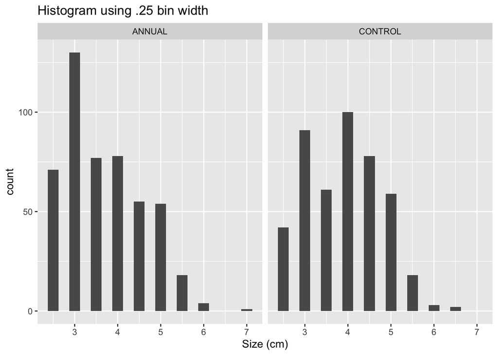

```r
ggplot(data = naples_urchins, aes(x= size)) +
  geom_histogram(bins = 20, binwidth = .25) +
  facet_wrap(~ treatment) +
  labs(title = "Histogram using .25 bin width", x="Size (cm)")
```

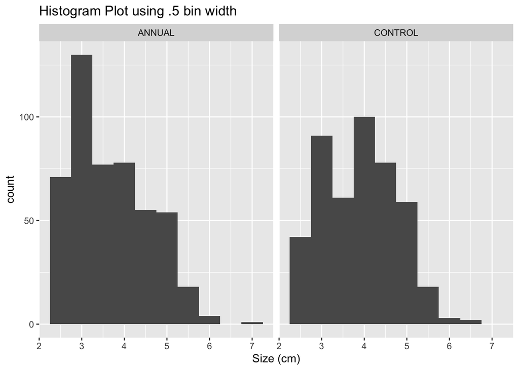

```r
ggplot(data = naples_urchins, aes(x= size)) +
  geom_histogram(bins = 20, binwidth = .5) +
  facet_wrap(~ treatment) +
  labs(title = "Histogram Plot using .5 bin width", x= "Size (cm)")
```

### 2.2 Quantile Quantile Plots

- Testing out QQ plots to assess normality of urchin sizes at the control plots vs the annual plots.
- QQ plots are plotting quantiles of data sets vs quantiles of another
- If the data is normally distributed, then we plot the quarantines vs theoretical normal quantiles, we’d find a linear relationship

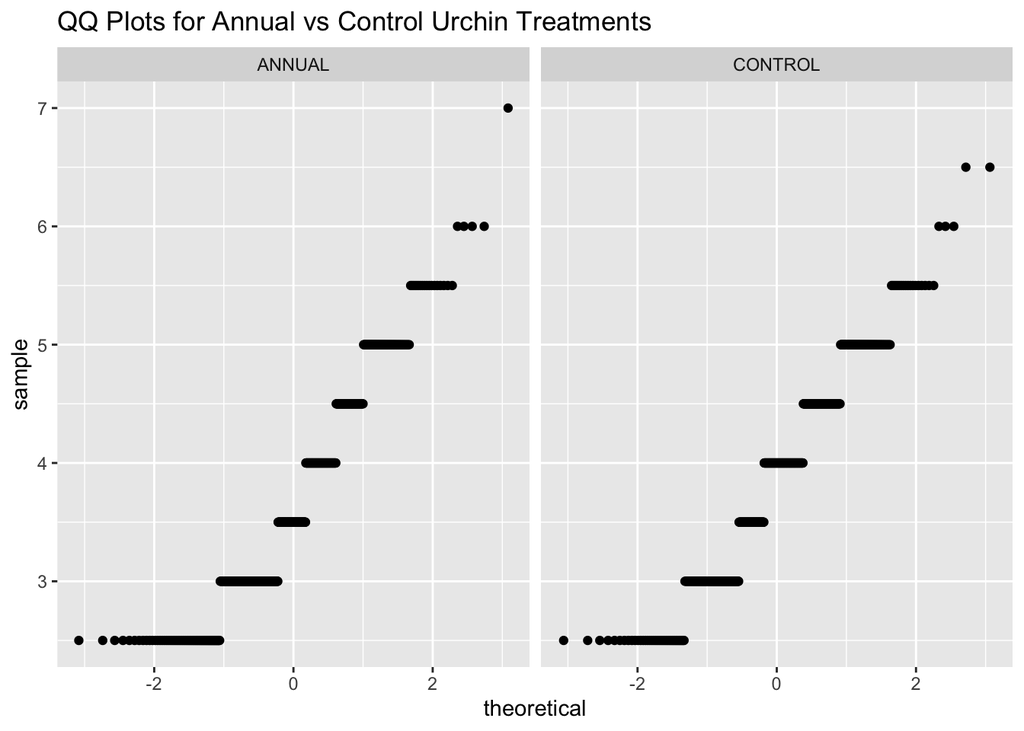

```r
ggplot(data = naples_urchins, aes(sample = size)) +
  geom_qq() +
  facet_wrap(~treatment) +
  labs(title = "QQ Plots for Annual vs Control Urchin Treatments")
```

#### QQ Plot analysis

The QQ plot of the control seems slightly more linear based on visual inspection as it seems to have less outliers on the high and low ends of the data compared to the annual treatment. In the annual treatment QQ plot, one can see that there seems to be more data spread around the lower end of the relationship, which would be expected based on the skew of the histogram. Based on these results I would support my intuition that the control plots look as if it they following more of a normal distribution of urchin sizes in comparison to the annual treatment plots.

# Section 3: Summary Table

- Creating summary table for both groups with the following:
- Mean
- Standard Deviation
- Sample Size

### 3.1 Grouping by Treatment and Then Summarizing by Sample Statistics

```r
naples_stats <- naples_urchins %>%
  group_by(treatment) %>%
  summarize(urchin_mean = round(mean(size), 1),
            urchin_median = round(median(size), 1),
            urchin_sd = round(sd(size),1),
            urchin_sample_size = n())
```

### 3.2 Updating Column Names in Naples Stats

```r
naples_stats <- rename(naples_stats, "Treatment" = "treatment")
naples_stats <- rename(naples_stats, "Urchin Size Mean (cm)" = "urchin_mean")
naples_stats <- rename(naples_stats, "Urchin Size Median (cm)" = "urchin_median")
naples_stats <- rename(naples_stats, "Urchin Size Standard Deviation (cm)" = "urchin_sd")
naples_stats <- rename(naples_stats, "Sample Size" = "urchin_sample_size")
```

### 3.3 Creating Summary Table

```r
naples_stats %>%
  kbl(caption = "Table 1: Sea Urchin Size Stats: Control vs Annual Treatment") %>%
  kable_styling(full_width = F, html_font = "Cambria")
```

Table 1: Sea Urchin Size Stats: Control vs Annual Treatment

| Treatment | Urchin Size Mean (cm) | Urchin Size Median (cm) | Urchin Size Standard Deviation (cm) | Sample Size |
| --- | --- | --- | --- | --- |
| ANNUAL | 3.7 | 3.5 | 0.9 | 488 |
| CONTROL | 3.9 | 4.0 | 0.9 | 454 |

# END TASK 4